# 36315 Project Final Report

Team T01

Erin Thomas and Junyuan Hu

### **Project title:** Comparison of mobile app features across various platforms (Apple VS Google) and timeframes (before and after COVID-19)

### **Introduction**

With the great range of mobile apps available in the market, we wanted to explore Apple App Store and Google Playstore app datasets. For this project we have addressed 2 main topics:

**1. Comparing and contrasting different apps and app genres between Apple App Store and Google Playstore**  
We have used 3 features of comparison between the various apps and genres, which are as follows:

1. Which app category has the most number of apps in the Apple App Store versus Google Playstore?
2. How has the price of apps changed throughout the years for each of the app categories, also comparing based on platform (Apple App store versus Google Playstore)?
3. How do the ratings of Google developed apps differ based on platform (Apple App store versus Google Playstore)?

**2. Investigating the changes in app characteristics in the Apple mobile app market before and after the COVID-19 outbreak**  
Based on information from the World Health Organization, COVID-19 was first reported on December 31, 2019, and therefore this time point was selected as the pre and post-pandemic cut-off point. Based on the changes in pricing and app version scores for different app genre categories, this project addresses three questions

1. Has there been an increase in the number of apps by an app category since the pandemic outbreak?
2. Has there been an increase in the number of app reviews for apps in various app categories before and after the pandemic?
3. Is there any difference in the app scores of the Finance apps before and after the pandemic?

We worked with the Mobile App Store and Google Playstore datasets which we found on Kaggle.  
*Apple App Store dataset: https://www.kaggle.com/datasets/gauthamp10/apple-appstore-apps*  
The Apple App Store dataset has 1230376 rows and 21 columns, which covers 1.2 Million+ apps available in the Apple App store along with 21 features that each of them possesses. Out of the 21 columns, relevant columns such as primary genre, user rating, price, released date, current version score, and so on were selected and exploratory and explanatory analyses were performed. While this dataset was used to compare and contrast with the google playstore dataset, it was also explored further to address the questions regarding the Apple mobile app market before and after the COVID-19 outbreak.  
*Google Playstore dataset: https://www.kaggle.com/datasets/gauthamp10/google-playstore-apps*  
The Google Playstore dataset has 2312944 rows and 24 columns, which covers 2.3 Million+ apps available in the Google Playstore along with 24 features that each of them possesses. Out of the 24 columns, similar to the Apple App store dataset, relevant columns such as category, rating, price, released date, and so on were selected and exploratory and explanatory analyses were performed. This dataset was primarily used to compare and contrast with the Apple App store dataset on various features such as price, version score and so on. Note: The data for both of the datasets have been collected by the author with the help of Python script (Scrapy) running on a cloud vm instance.

### **Importing libraries & Reading the datasets**

```r
library(tidyverse)
library(lubridate)
library(scales)
library(psych)
library(ggpubr)
library(ggsci)
library(ggrepel)
```

**Apple App store dataset**

```r
apple <- read_csv("appleAppData.csv")
dim(apple)
```

```
## [1] 1230376      21
```

Making a subset of relevant columns from the larger Apple App store dataset

```r
appleApps <- apple %>%
  select(App_Name, Primary_Genre, Average_User_Rating, Free, Price, Released, Current_Version_Score, Current_Version_Reviews, Content_Rating)
glimpse(appleApps)
```

```
## Rows: 1,230,376
## Columns: 9
## $ App_Name                <chr> "A+ Paper Guide", "A-Books", "A-books", "A-F B…
## $ Primary_Genre           <chr> "Education", "Book", "Book", "Book", "Referenc…
## $ Average_User_Rating     <dbl> 0.00000, 5.00000, 0.00000, 0.00000, 0.00000, 0…
## $ Free                    <lgl> TRUE, TRUE, TRUE, FALSE, TRUE, TRUE, TRUE, TRU…
## $ Price                   <dbl> 0.00, 0.00, 0.00, 2.99, 0.00, 0.00, 0.00, 0.00…
## $ Released                <dttm> 2017-09-28 03:02:41, 2015-08-31 19:31:32, 202…
## $ Current_Version_Score   <dbl> 0.00000, 5.00000, 0.00000, 0.00000, 0.00000, 0…
## $ Current_Version_Reviews <dbl> 0, 1, 0, 0, 0, 0, 0, 0, 0, 0, 1285, 1839, 242,…
## $ Content_Rating          <chr> "4+", "4+", "4+", "4+", "4+", "4+", "4+", "4+"…
```

**Google Playstore dataset**

```r
google <- read_csv("Google-Playstore.csv")
dim(google)
```

```
## [1] 2312944      24
```

Making a subset of relevant columns from the larger Google Playstore dataset

```r
googleApps <- google %>%
  select(`App Name`, Category, Rating, Free, Price, Released)
glimpse(googleApps)
```

```
## Rows: 2,312,944
## Columns: 6
## $ `App Name` <chr> "Gakondo", "Ampere Battery Info", "Vibook", "Smart City Tri…
## $ Category   <chr> "Adventure", "Tools", "Productivity", "Communication", "Too…
## $ Rating     <dbl> 0.0, 4.4, 0.0, 5.0, 0.0, 0.0, 4.5, 2.0, 0.0, 4.7, 4.9, 0.0,…
## $ Free       <lgl> TRUE, TRUE, TRUE, TRUE, TRUE, TRUE, TRUE, TRUE, TRUE, TRUE,…
## $ Price      <dbl> 0, 0, 0, 0, 0, 0, 0, 0, 0, 0, 0, 0, 0, 0, 0, 0, 0, 0, 0, 0,…
## $ Released   <chr> "Feb 26, 2020", "May 21, 2020", "Aug 9, 2019", "Sep 10, 201…
```

### **Section 1: Comparing and contrasting different apps and app genres between Apple App Store and Google Playstore**

The Apple App Store and the Google Playstore are the different platforms for mobile apps of various genres. Using side-by-side bar charts, pie charts, and heatmaps, we wanted to compare and contrast how different app genres and their features differ based on the platform, which is covered in this section.

#### **a. Which app category has the most number of apps in the Apple App Store versus Google Playstore?**

We wanted to learn about which app genre has the most number of apps and how it changes based on the platform, for which we explore the count of the number of apps in each genre for the Apple App Store and Google Playstore.

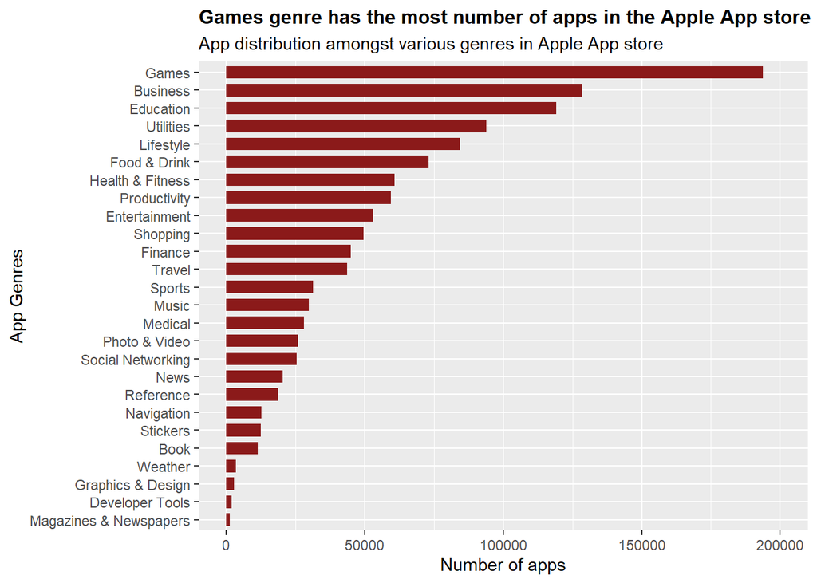

```r
appleApps %>%
  count(Primary_Genre) %>%
  ggplot(aes(x=reorder(Primary_Genre,n), y=n)) +
  geom_col(width=0.7,  fill="firebrick4")  +
  coord_flip() +
  ylim(0, 200000) +
  labs(title = "Games genre has the most number of apps in the Apple App store",
       subtitle = "App distribution amongst various genres in Apple App store",
       x = "App Genres", y = "Number of apps") +
  theme(plot.title = element_text(size = 12,face="bold"))
```

The above graph shows that the Games category is the one with the most number of apps in the Apple App Store, followed by the Business, Education, and Utilities categories.

Now, let’s compare it to the app categories in the Google Playstore

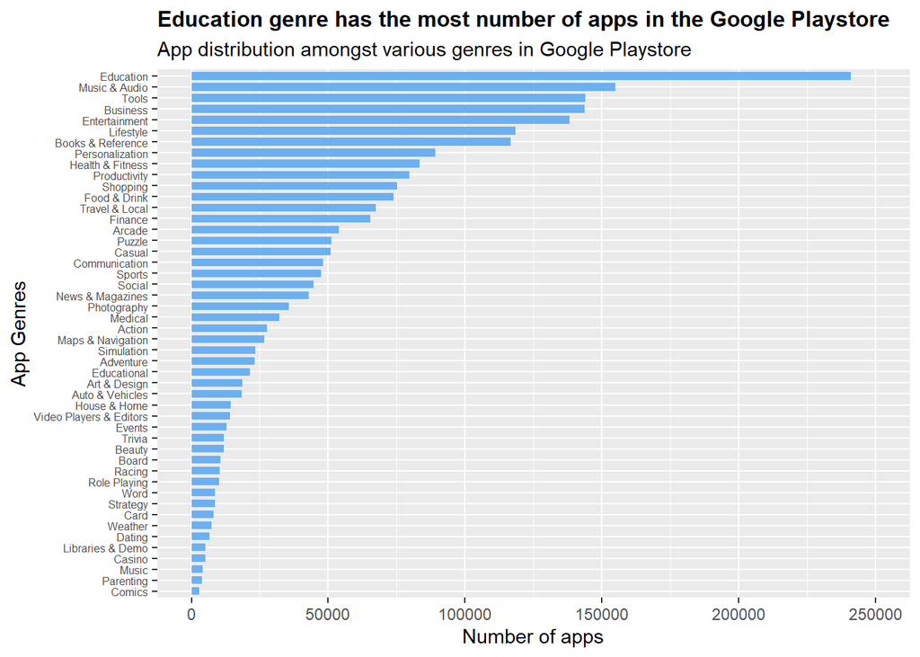

```r
googleApps %>%
  count(Category) %>%
  ggplot(aes(x=reorder(Category,n), y=n)) +
  geom_col(width=0.7,  fill="#6cb0f1") +
  coord_flip() +
  ylim(0, 250000) +
  labs(title = "Education genre has the most number of apps in the Google Playstore",
       subtitle = "App distribution amongst various genres in Google Playstore",
       x = "App Genres", y = "Number of apps") +
  theme(axis.text.y = element_text(size = 6), plot.title = element_text(size = 12,face="bold"))
```

For Google Playstore, we observe that the Education category has the highest number of apps. We have deduced the probable assumption that the number of apps in the game category in Google Playstore isn’t as high as compared to Apple App Store, due to there being no unified game category in the Google Playstore dataset and it being fragmented as action, arcade and so on. Additionally, “Google Play for Education is an extension of Google Play designed for schools. Here educators can discover Android and Chrome apps approved by teachers for teachers, as well as educational videos and a collection of classic books for their classroom.” (cited from https://android-doc.github.io/distribute/googleplay/edu/about.html). This aspect could also be an additional factor for the increased number of educational apps in Google Playstore.

Now, ultimately, we want to how the app numbers compared for common app genres on both the platforms, for which we displayed the next graph. We took the common app genres in both the datasets and compare their numbers as follows

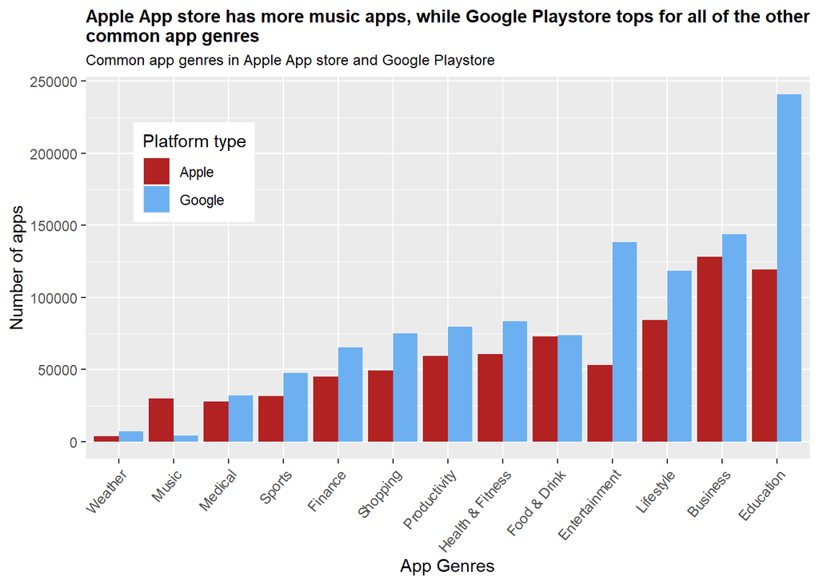

```r
appleAppCategory <- appleApps %>%
  group_by(Primary_Genre) %>%
  summarize(Apple = n())

googleAppCategory <- googleApps %>%
  group_by(Category) %>%
  summarize(Google = n())

googleAppCategory %>%
  inner_join(appleAppCategory,  by = c("Category" = "Primary_Genre")) %>%
  pivot_longer(cols = Google:Apple,
                names_to = 'type',
               values_to = 'count') %>%
  ggplot(aes(x=reorder(Category, count), y=count, fill = type)) +
  geom_col(position = "dodge") +
  scale_fill_manual(values = c("firebrick", "#6cb0f1")) +
  labs(title = "Apple App store has more music apps, while Google Playstore tops for all of the other \ncommon app genres",
       subtitle = "Common app genres in Apple App store and Google Playstore",
       x = "App Genres", y = "Number of apps", fill = "Platform type") +
  theme(axis.text.x = element_text(angle = 50, vjust=1, hjust= 1), plot.title = element_text(size = 11, face="bold"),
        plot.subtitle = element_text(size = 9,), legend.position=c(0.15,0.75))
```

As this graph demonstrates, Google PlayStore has more apps in almost every app category other than music apps. When we explored further on this particular observation, we understood that the following information could have had some direct/indirect consequences on the music app ratings in Google Playstore: Google Playstore deprecated their Google Play Music service and switched over to Youtube Music. “Thousands of die-hard Google Play Music users have left 1-star ratings on YouTube Music’s Play Store page. The resultant is a greater number of 1-star ratings than the 5-star ones.” (cited from https://piunikaweb.com/2020/11/07/youtube-music-app-garners-lots-of-1-star-play-store-ratings-but-all-is-not-lost-for-google/). It is rather interesting to observe this possible background reasoning behind such an observation.

#### **b. How has the price of apps changed throughout the years for each of the app categories, also comparing based on platform (Apple App store versus Google Playstore)?**

Next, we wanted to understand the pricing aspect of apps such as how many apps are free on each platform and how has the price of apps changed throughout the years for each of the app categories.

Firstly, to get a better understanding of the distribution of the free and paid apps in the Apple App Store and Gooogle Playstore, we represented this data in a pie chart

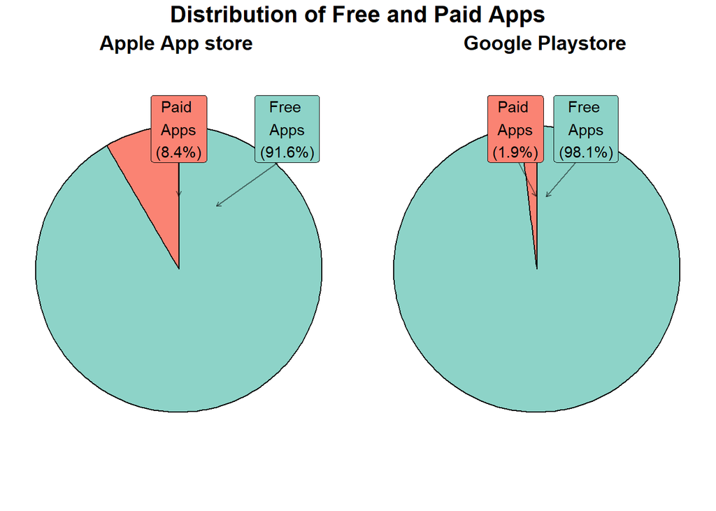

```r
appleAppsFree <- appleApps %>%
  count(Free) %>%
  mutate(percent = round(n / sum(n), 3)*100,
         text_y = cumsum(percent) - percent,
         label = paste0(ifelse(Free==TRUE, "Free \nApps", "Paid \nApps"), "\n(", percent, "%)")) %>%
  ggplot(aes(x="", y = percent, fill = Free)) +
  geom_bar(stat = "identity", width = 1, color = "black") +
  geom_label_repel(aes(label = label, y = text_y), point.padding = NA,
    nudge_x = 1, force = 0.5, force_pull = 0, segment.alpha=0.5,
    arrow=arrow(length = unit(0.05, "inches"),ends = "last", type = "open")) +
  coord_polar("y", start = 0) +
  scale_fill_manual(values = c("#fa8373", "#8dd3c8")) +
  theme_void() +
  theme(legend.position = "none", plot.title = element_text(hjust = 0.5))

googleAppsFree <- googleApps %>%
  count(Free) %>%
  mutate(percent = round(n / sum(n), 3)*100,
         text_y = cumsum(percent) - percent,
         label = paste0(ifelse(Free==TRUE, "Free \nApps", "Paid \nApps"), "\n(", percent, "%)")) %>%
  ggplot(aes(x="", y = percent, fill = Free)) +
  geom_bar(stat = "identity", width = 1, color = "black") +
  geom_label_repel(aes(label = label, y = text_y), point.padding = NA,
    nudge_x = 1, force = 0.5, force_pull = 0, segment.alpha=0.5,
    arrow=arrow(length = unit(0.05, "inches"),ends = "last", type = "open")) +
  coord_polar("y", start = 0) +
  scale_fill_manual(values = c("#fa8373", "#8dd3c8")) +
  theme_void() +
  theme(legend.position = "none", plot.title = element_text(hjust = 0.5))

plot <- ggarrange(appleAppsFree,googleAppsFree, hjust=-0.65,labels=c("Apple App store","Google Playstore"))
annotate_figure(plot, top = text_grob("Distribution of Free and Paid Apps", face = "bold", size = 16))
```

From the graph, we can see that both platforms have more than 90% of their apps for free. To compare the proportion of paid apps, Apple App Store has more paid apps than Google Playstore.

Now, to go into the specifics of average prices of apps in each app category and their changes throughout the years, we used heatmaps, one of each platform.

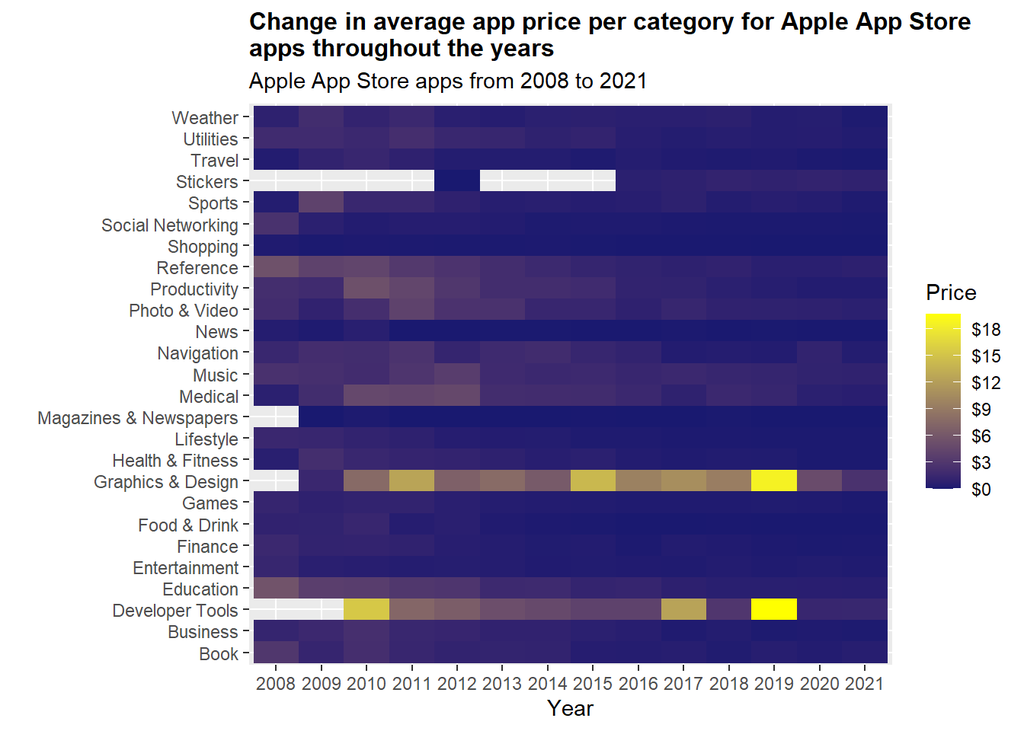

```r
appleReleaseYear <- appleApps %>%
  mutate(Released = year(Released))

appleReleaseYear %>%
  filter(!is.na(Price), !is.na(Released)) %>%
  group_by(Primary_Genre,Released) %>%
  summarize(meanPrice = mean(Price)) %>%
  ggplot(aes(x = as.character(Released), y = Primary_Genre, fill = meanPrice)) +
  geom_tile() +
  scale_fill_gradient(low = "#191970", high = "yellow",
                      breaks = seq(0, 100, 3),
                     labels = dollar, name = "Price") +
  labs(title="Change in average app price per category for Apple App Store\napps throughout the years",
       subtitle="Apple App Store apps from 2008 to 2021", x="Year", y="") +
   theme(plot.title = element_text(size=12, face="bold"))
```

For the Apple App store, we observed that most app genres have seen a relative decrease in their average prices from 2008 to 2021. But particularly, in the year 2019, Graphics & Design and Developer Tools app categories saw a spike in their prices, which then followed a decrease in the following years.

```r
googleReleaseYear <- googleApps %>%
  separate(Released, c("date","Released"), ", ") %>%
  select(-date)
```

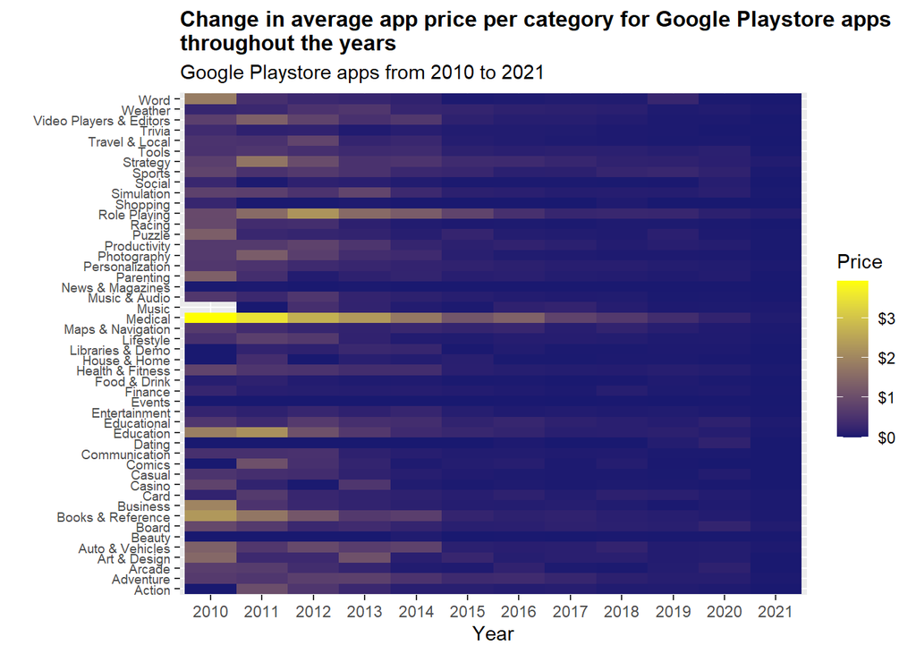

```r
googleReleaseYear %>%
  filter(!is.na(Price), !is.na(Released)) %>%
  group_by(Category,Released) %>%
  summarize(meanPrice = mean(Price)) %>%
  ggplot(aes(x = Released, y = Category, fill = meanPrice)) +
  geom_tile()+
  scale_fill_gradient(low = "#191970", high = "yellow",
                     labels = dollar, name = "Price") +
  theme(axis.text.y = element_text(size = 7)) +
  labs(title="Change in average app price per category for Google Playstore apps \nthroughout the years",
       subtitle="Google Playstore apps from 2010 to 2021", x="Year", y="")+
   theme(plot.title = element_text(size=12, face="bold"))
```

For the Google Playstore, we observed that almost all of the app genres have seen a relative decrease in their average prices from 2010 to 2021. Relatively, only the Medical apps category had higher prices in 2010 which dressed gradually over the years. And, in 2021, overall all apps seem to be leaning towards being less than $1 or free.

#### **c. How do the ratings of Google developed apps differ based on platform (Apple App store versus Google Playstore)?**

Lastly, within this section, we also wanted to address a particular question of curiosity, which is: How do the ratings of Google-developed apps differ based on platform (Apple App store versus Google Playstore)? Google developed apps include google classroom, google docs, and so on.

For this graph, we filtered through all the common google developed apps available on both the platforms from which we calculated the difference in ratings, which we plotted as a diverging bar chart.

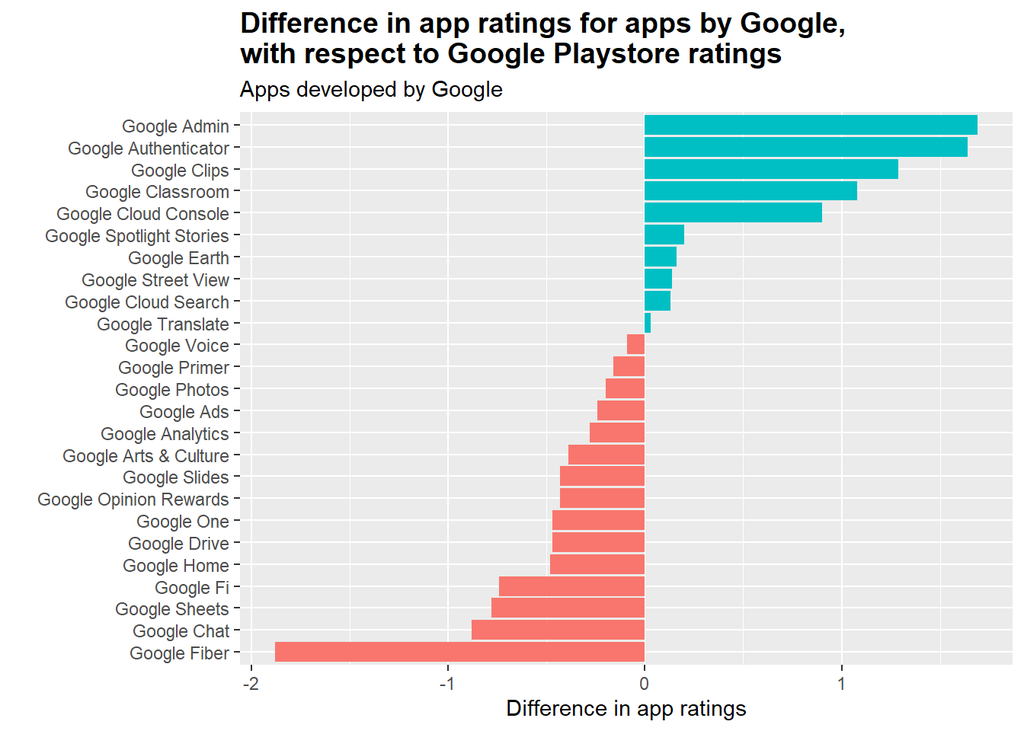

```r
appleApps %>%
  inner_join(googleApps, by=c("App_Name" = "App Name")) %>%
  select(App_Name, Google_Rating = Rating, Apple_Rating = Average_User_Rating) %>%
  filter(!(Google_Rating == 0 & Apple_Rating == 0)) %>%
  mutate(difference = round(Google_Rating - Apple_Rating, 2)) %>% #
  filter(startsWith(App_Name, "Google ")) %>%
  arrange(difference) %>%
  ggplot(aes(x = difference, y = reorder(App_Name, difference), fill=difference >0)) +
  geom_col() +
  labs(title="Difference in app ratings for apps by Google, \nwith respect to Google Playstore ratings",
       subtitle="Apps developed by Google", x = "Difference in app ratings", y="") +
  theme(plot.title = element_text(size = 14, face="bold"), plot.subtitle = element_text(size = 11), legend.position="none")
```

From this graph, we observed that more than half of the Google apps have a higher rating in Apple App Store (denoted by the negative difference values, since the difference in ratings is taken with respect to the Google Playstore ratings). But a correlation that we also observed is as follows: Earlier we observed that Google Playstore had the most number of Educational Apps and how Google play has a dedicated section for education within their app demographic. Here, we also observed the example of Google Classroom having higher ratings in the Google Playstore which reiterates the emphasis that Google Playstore gives to education apps, and the fact that the users also addressed this aspect is prominent with their increased rating on the Google Playstore platform as compared to the ratings for the same app on App App Store.

### **Section 2: Investigating the changes in app characteristics in the Apple mobile app market before and after the COVID-19 outbreak**

Now, we want to focus only on the Apple App Store market to investigate the changes in app characteristics of various categories in the Apple App Market before and after the pandemic. We used bar charts, heat maps, and density maps to analyze them.

#### Basic statistical analysis

```r
appleApps <- na.omit(appleApps) %>%
  mutate(Released = as.Date(Released))
```

```r
before <- appleApps %>%
  filter(Released <='2019-12-31')
describe(before[,c("Released","Price","Current_Version_Score")])
```

```
##                       vars      n mean   sd median trimmed  mad min    max
## Released                 1 784276  NaN   NA     NA     NaN   NA Inf   -Inf
## Price                    2 784276 0.64 7.43      0    0.01 0.00   0 999.99
## Current_Version_Score    3 784276 2.06 2.15      1    1.95 1.48   0   5.00
##                        range  skew kurtosis   se
## Released                -Inf    NA       NA   NA
## Price                 999.99 62.46  6024.41 0.01
## Current_Version_Score   5.00  0.26    -1.74 0.00
```

```r
TimeHorizonBefore <- max(before$Released)-min(before$Released)
```

```r
after <- appleApps %>%
  filter(Released >'2019-12-31')
describe(after[,c("Released","Price","Current_Version_Score")])
```

```
##                       vars      n mean   sd median trimmed mad min    max
## Released                 1 445609  NaN   NA     NA     NaN  NA Inf   -Inf
## Price                    2 445609 0.26 5.75      0    0.00   0   0 999.99
## Current_Version_Score    3 445609 1.31 2.09      0    1.02   0   0   5.00
##                        range   skew kurtosis   se
## Released                -Inf     NA       NA   NA
## Price                 999.99 112.46 16811.30 0.01
## Current_Version_Score   5.00   1.03    -0.85 0.00
```

```r
TimeHorizonAfter <- max(after$Released)-min(after$Released)
```

#### **a. Has there been an increase in the number of apps by an app category since the pandemic outbreak?**

We wanted to explore this question to see whether the online life during the pandemic had affected the number of apps in each app category and if so, which categories showed the most increase in app numbers. For the same, we used a side-by-side bar chart faceted by the increase/decrease in the number of apps in the Apple App Store.

```r
covid_division <- appleApps %>%
  mutate(Division = ifelse(Released<='2019-12-31',"Before Covid-19","After Covid-19")) %>%
  select(Primary_Genre, Content_Rating, Released, Price, Current_Version_Score, Current_Version_Reviews, Division)
```

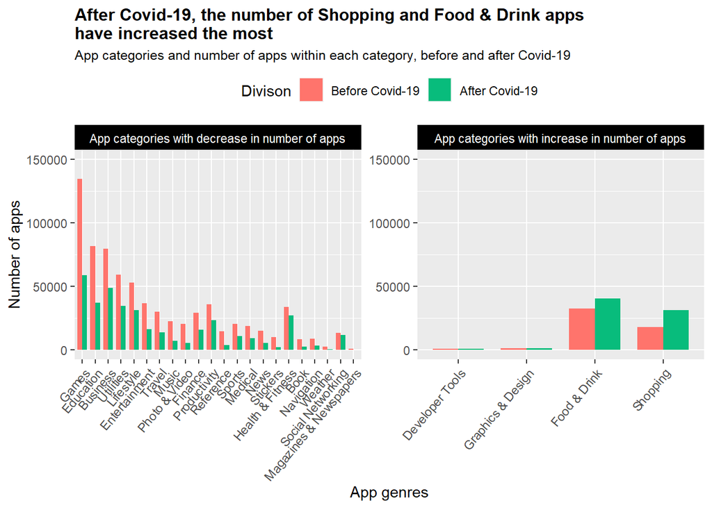

```r
covid_division %>%
  group_by(Primary_Genre,Division) %>%
  summarize(total_apps_num = n()) %>%
  pivot_wider(names_from = 'Division', values_from = 'total_apps_num') %>%
  mutate(difference = `After Covid-19` - `Before Covid-19`, sign = ifelse(difference/abs(difference) == -1, "App categories with decrease in number of apps", "App categories with increase in number of apps")) %>%

  pivot_longer(cols = `After Covid-19`:`Before Covid-19`,
                names_to = 'Division', values_to = "total_apps_num") %>%

  ggplot(aes(x=reorder(Primary_Genre,difference),y=total_apps_num,
             fill=factor(Division, levels = c("Before Covid-19", "After Covid-19")))) +
  geom_col(width = 0.75, position = 'dodge') +
  scale_fill_manual(values=c("Before Covid-19"="#ff746c", "After Covid-19" = "#08bc7c")) +
  scale_y_continuous(labels = comma) +
  ylim(0,150000) +
  facet_wrap(~sign, scales = "free") +
  labs(title = "After Covid-19, the number of Shopping and Food & Drink apps\nhave increased the most",
       subtitle = "App categories and number of apps within each category, before and after Covid-19",
       x="App genres", y="Number of apps", fill = "Divison") +
  theme(plot.title = element_text(size = 12, face="bold"), plot.subtitle = element_text(size = 9.5),
        axis.text.x = element_text(angle = 50, vjust=1, hjust= 1), legend.position="top",
        strip.background =element_rect(fill="black"),strip.text = element_text(colour = 'white'))
```

From the faceted graph above, we can see that the number of Shopping and Food & Drink apps have increased significantly after the outbreak. However, in general, the majority of the app categories have seen a decrease in the number of apps post-covid.

#### **b. Has there been an increase in the number of app reviews for apps in various app categories before and after the pandemic?**

Next, we wanted to observe the increase/decrease in the number of app reviews for apps in various app categories before and after the pandemic. We used a heatmap to observe that with respect to an additional factor, which is how children-friendly apps are, which was taken into account by observing the app review numbers with respect to the levels of content rating.

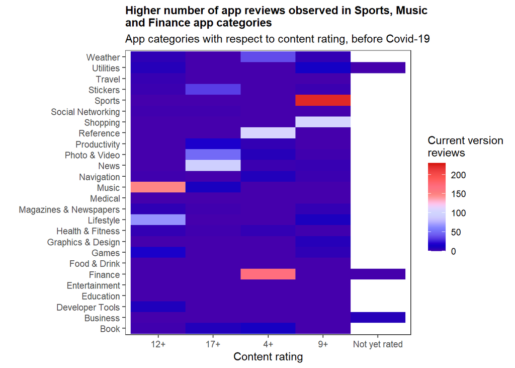

```r
before %>%
  filter(Current_Version_Reviews<=quantile(Current_Version_Reviews,0.95)) %>%
  ggplot(aes(x=Content_Rating,y=Primary_Genre,fill=Current_Version_Reviews))+
  theme_bw()+
  theme(panel.grid.major = element_blank()) +
  theme(legend.key=element_blank()) +
  geom_tile()+
  scale_fill_gsea() +
  labs(title = "Higher number of app reviews observed in Sports, Music\nand Finance app categories",
       subtitle = "App categories with respect to content rating, before Covid-19",
       x="Content rating", y="", fill = "Current version\nreviews") +
  theme(plot.title = element_text(size = 11, face="bold"))
```

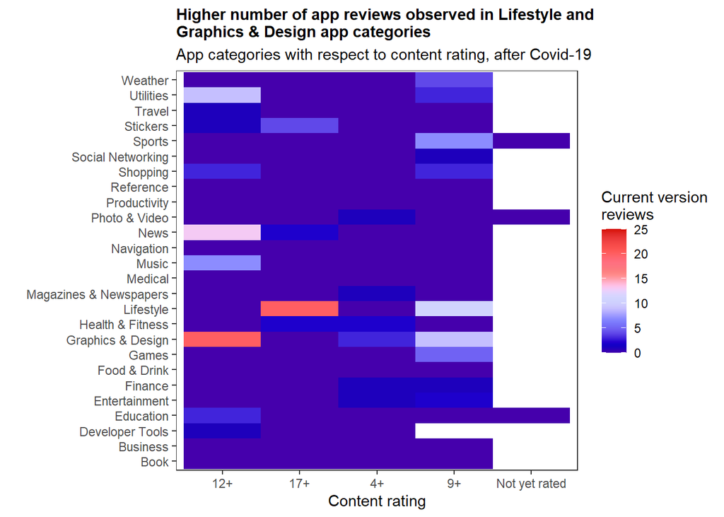

```r
after %>%
  filter(Current_Version_Reviews<=quantile(after$Current_Version_Reviews,0.95)) %>%
  ggplot(aes(x=Content_Rating,y=Primary_Genre,fill=Current_Version_Reviews))+
  theme_bw()+
  theme(panel.grid.major = element_blank()) +
  theme(legend.key=element_blank()) +
  geom_tile()+
  scale_fill_gsea()+
  labs(title = "Higher number of app reviews observed in Lifestyle and\nGraphics & Design app categories",
       subtitle = "App categories with respect to content rating, after Covid-19",
       x="Content rating", y="", fill = "Current version\nreviews") +
  theme(plot.title = element_text(size = 11, face="bold"))
```

As observed from both the graphs, before the pandemic, there is a higher number of app reviews observed in the Sports, Music, and Finance app categories, and a higher number of app reviews were observed in the Lifestyle and Graphics & Design app categories after the pandemic.

#### **c. Is there any difference in the app scores of the Finance apps before and after the pandemic?**

Lastly, now that observed the decline in the app review numbers for Finance apps before and after the pandemic, we also wanted to particularly explore its app scores too. Firstly, we used density graphs to have an overall look at the score density for all app categories before and after Covid-19. Then we focussed on the Finance apps and their density graphs before and after Covid-19.

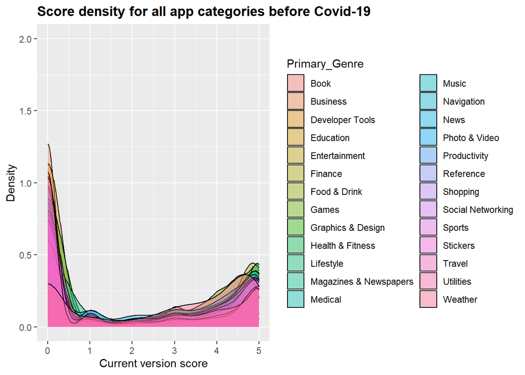

```r
before %>%
  ggplot(aes(x=Current_Version_Score)) +
  geom_density(aes(fill=Primary_Genre),alpha=0.4) +
  labs(title="Score density for all app categories before Covid-19",
       x="Current version score", y="Density") +
  ylim(0,2) +
  theme(plot.title = element_text(face="bold"))
```

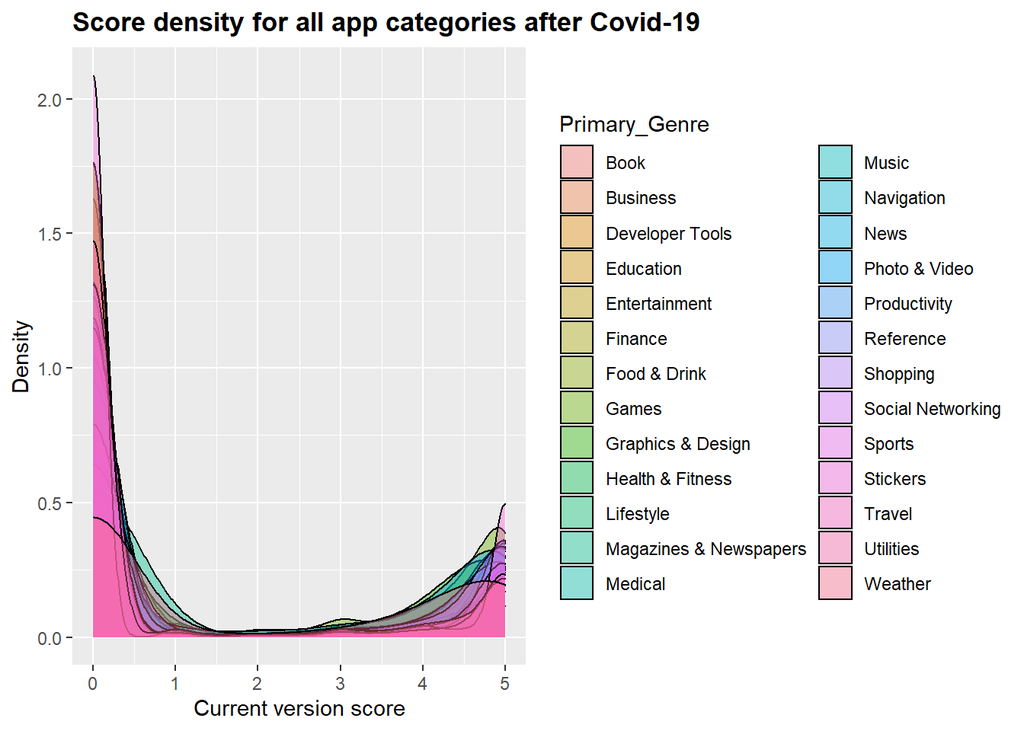

```r
after %>%
  ggplot(aes(x=Current_Version_Score)) +
  geom_density(aes(fill=Primary_Genre),alpha=0.4) +
  labs(title="Score density for all app categories after Covid-19",
       x="Current version score", y="Density") +
  theme(plot.title = element_text(face="bold"))
```

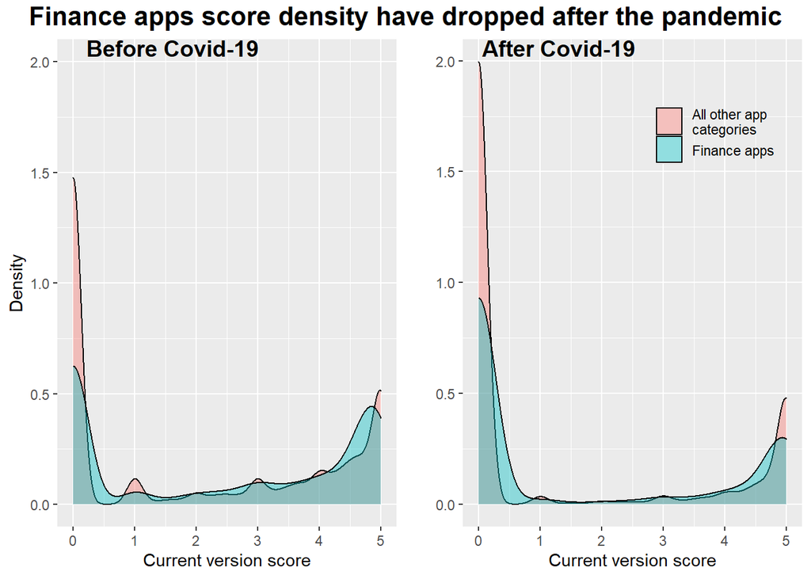

```r
finance_apps_before <- before %>%
  mutate(finance = ifelse(Primary_Genre != "Finance","All other app\ncategories","Finance apps")) %>%
  ggplot(aes(x=Current_Version_Score)) +
  geom_density(aes(fill=finance),alpha=0.4) +
  theme(legend.position="none") +
  labs(x="Current version score", y="Density") +
  ylim(0,2)

finance_apps_after <- after %>%
  mutate(finance = ifelse(Primary_Genre != "Finance","All other app\ncategories","Finance apps")) %>%
  ggplot(aes(x=Current_Version_Score)) +
  geom_density(aes(fill=finance),alpha=0.4) +
  theme(legend.position=c(0.75,0.83), legend.background=element_blank()) +
  labs(x="Current version score", y="", fill="")

finance_score_plot <- ggarrange(finance_apps_before,finance_apps_after,labels=c("Before Covid-19","After Covid-19"))
annotate_figure(finance_score_plot, top = text_grob("Finance apps score density have dropped after the pandemic", face = "bold", size = 16))
```

As we can observe from the graphs, the overall distribution of scores has a downward trend, and it has become more left-leaning after the pandemic. The finance apps score of 5 seems to have fallen while the app score of 0 has seen a rise.

##### **t-test**

Additionally, we also used a t-test to assist in checking whether the mean value of the Finance app score has changed before and after the pandemic.

```r
before_finance <- before %>%
  filter(Primary_Genre == "Finance")
after_finance <- after %>%
  filter(Primary_Genre == "Finance")

t.test(before_finance$Current_Version_Score,after_finance$Current_Version_Score,var.equal = FALSE)
```

```
##
##  Welch Two Sample t-test
##
## data:  before_finance$Current_Version_Score and after_finance$Current_Version_Score
## t = 44.329, df = 32526, p-value < 2.2e-16
## alternative hypothesis: true difference in means is not equal to 0
## 95 percent confidence interval:
##  0.8987343 0.9818865
## sample estimates:
## mean of x mean of y
##  2.443152  1.502842
```

As observed from the results of the t-test, the p-value is less than 0.05. Hence, we can reject the invalid hypothesis and accept the alternative hypothesis, and conclude that there is a significant difference between the overall mean of app scores for the Finance class before and after the pandemic.

### **Conclusion**

While exploring the Apple App Store and Google Playstore datasets, we have found out that while the games category tops in Apple App Store and the Education apps tops in Google Playstore and music apps were the only common category in which Apple App Store overruled. Next, we observed a relative decrease in the prices for apps in each category. We also found that google developed apps had higher user ratings on the Apple platform.

The changes in-app characteristics of various categories in the Apple App Market before and after the pandemic were often analyzed using the bar chart, heat map, and density map. It is clear that the number of Shopping and Food & Drink apps have increased significantly after the outbreak. While the app reviews for sports-related apps have drastically declined, that graphic design and related apps have significantly soared. Finally, the results of the two-sample T-test revealed that there was a significant difference between the average of Finance-related apps post-pandemic and pre-pandemic, and the score dropped.

For future work, using the same datasets, we would like to explore the trends and features specific to social media networking apps and their differences based on the platform (Apple App Store and Google Playstore). Additionally, we would like to examine deeper on games apps. Our first approach for this project was to do research on how Covid-19 affects people’s lifestyles when we have more time while staying at home. However, we had a hard time finding the raw data of the two approaches. By examining games and video apps, we could possibly come up with more visualizations and more research questions.